# Data Pre-processing

[Hui Lin](http://scientistcafe.com)

[figure not shown]

2018-06-11

## Data can be dirty and usually is!

[figure not shown]

## Data types

1. Raw data
2. Technically correct data
3. Data that is proper for the model
4. Summarized data
5. Data with fixed format

## Preprocessing Map

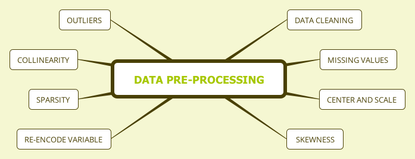

## Data Cleaning

```r
sim.dat <- read.csv("https://raw.githubusercontent.com/happyrabbit/DataScientistR/master/Data/SegData.csv ")
summary(sim.dat)
```

[output not shown]

## Data Cleaning

- How to deal with that?

```r
# set problematic values as missings
sim.dat$age[which(sim.dat$age>100)]<-NA
sim.dat$store_exp[which(sim.dat$store_exp<0)]<-NA
# see the results
summary(subset(sim.dat,select=c("age","income")))
```

## Missing Values

- Is there any auxiliary information?
- Is missing a random occurrence?
- What is the purpose of modeling?

## Missing Values: median/mode

- `impute()` function in `imputeMissings` package

```r
# save the result as another object
demo_imp<-impute(sim.dat,method="median/mode")
# check the first 5 columns, there is no missing values in other columns
summary(demo_imp[,1:5])
```

- `preProcess()` function in `caret` package

```r
imp<-preProcess(sim.dat,method="medianImpute")
demo_imp2<-predict(imp,sim.dat)
summary(demo_imp2[,1:5])
```

## Missing Values: K-nearest neighbors

- `preProcess()` function in `caret` package

```r
imp<-preProcess(sim.dat,method="knnImpute",k=5)
# need to use predict() to get KNN result
demo_imp<-predict(imp,sim.dat)
```

## Solve the problem

```r
# find factor columns
imp<-preProcess(sim.dat,method="knnImpute",k=5)
idx<-which(lapply(sim.dat,class)=="factor")
demo_imp<-predict(imp,sim.dat[,-idx])
summary(demo_imp[,1:3])
```

## Missing Values: Bagging Tree

- Bagging (Bootstrap aggregating)
- Powerful
- Computation is much more intense than KNN

```r
imp<-preProcess(sim.dat,method="bagImpute")
demo_imp<-predict(imp,sim.dat)
summary(demo_imp[,1:5])
```

## Centering and Scaling

- Easy to DIY

```r
income<-sim.dat$income
# calculate the mean of income
mux<-mean(income,na.rm=T)
# calculate the standard deviation of income
sdx<-sd(income,na.rm=T)
# centering
tr1<-income-mux
# scaling
tr2<-tr1/sdx
```

- Use `preProcess()`

```r
sdat<-subset(sim.dat,select=c("age","income"))
# set the "method" option
trans<-preProcess(sdat,method=c("center","scale"))
# use predict() function to get the final result
transformed<-predict(trans,sdat)
```

## Resolve Skewness

- `describe(sim.dat)`
- Box-Cox transformation

```r
# select the two columns and save them as dat_bc
dat_bc<-subset(sim.dat,select=c("store_trans","online_trans"))
(trans<-preProcess(dat_bc,method=c("BoxCox")))
```

Use `predict()` to get the transformed result:

```r
transformed<-predict(trans,dat_bc)
```

## Resolve Outliers

- Defining outliers is hard
- Basic visualizations: box-plot, histogram and scatterplot
- Statistical methods to define outliers

## Z-score and modified Z-score

- Z-score

$$Z_{i}=\frac{Y_{i}-\bar{Y}}{s}$$
where $\bar{Y}$ and $s$ are mean and standard deviation for $Y$

- Modified Z-score

$$M_{i}=\frac{0.6745(Y_{i}-\bar{Y})}{MAD}$$

where MAD is the median of a series of $|Y_{i} - \bar{Y}|$, called the median of the absolute dispersion

- Iglewicz and Hoaglin suggest that the points with the Z-score greater than 3.5 are possible outliers

## Collinearity

- Define: `corrplot()`
- Algorithm to remove a minimum number of predictors to ensure all pairwise correlations are below a certain threshold
1. Calculate the correlation matrix of the predictors.
2. Determine the two predictors associated with the largest absolute pairwise correlation (call them predictors A and B).
3. Determine the average correlation between A and the other variables. Do the same for predictor B.
4. If A has a larger average correlation, remove it; otherwise, remove predictor B.
5. Repeat Step 2-4 until no absolute correlations are above the threshold.
- How to choose the threshold?

## Sparse Variables

- Detecting rules:
1. The fraction of unique values over the sample size
2. The ratio of the frequency of the most prevalent value to the frequency of the second most prevalent value.

## Re-encode Dummy Variables

- `class.ind()` from `nnet` package

```r
dumVar<-class.ind(sim.dat$gender)
head(dumVar)
```

- `dummyVars()` from `caret`

```r
dumMod<-dummyVars(~gender+house+income,
                  data=sim.dat,
                  # use "origional variable name + level" as new name
                  levelsOnly=F)
head(predict(dumMod,sim.dat))
```

## Other Notes

- Two options: Cloud and GPU (NVIDIA)
- Hyperparameter: pre-trained model
- AI application: Bayesian accuracy
- AlexNet: https://papers.nips.cc/paper/4824-imagenet-classification-with-deep-convolutional-neural-networks.pdf
- Hands-on: https://github.com/happyrabbit/Talks/tree/master/2018_06_ShortCourse